# Heatmap de Genes Diferencialmente Expresados (DEGs)

Heatmap de Genes Diferencialmente Expresados (DEGs) Dra. Linda Aimara Kempis Calanis 2025-11-26

## 📌 1. Leer la tabla con genes diferencialmente expresados (DEGs)

```r
### Heatmap
# Leer la tabla con resultados de expresión diferencial.
# Esta tabla proviene del análisis realizado con edgeR.
library(here)

lfc <- read.table(here::here("dato_tsv", "Neo_vs_Adultos_DiffExp_edgeR.txt"))

# Visualizamos la tabla para entender su contenido
View(lfc)
```

## 📌 2. Filtrar genes con cambios relevantes (logFC y expresión)

Aquí seleccionamos los genes más representativos:

**|logFC| ≥ 2 → cambios grandes entre grupos**

**|logCPM| ≥ 2 → expresión suficientemente alta**

### ¿Qué es logFC?

logFC = log fold change Es la medida que cuantifica cuánto cambia la expresión de un gen entre dos condiciones, por ejemplo:

Neonatos vs Adultos

Tratado vs Control

El símbolo | | significa valor absoluto, es decir, ignorar el signo.

Un valor de: |log2(FC)| ≥ 2 se traduce a: Fold change ≥ 2^2 = 4 veces

### **Interpretación biológica**

✔ logFC ≥ +2

El gen está sobreexpresado:

✔ logFC ≤ −2

```r
# Cargar librerías para manipulación de datos
library(tidyverse)
library(dplyr)

# Ordenamos por logFC y filtramos con criterios biológicamente relevantes
lfc2 <- lfc %>%
  arrange(desc(logFC)) %>%                                # Ordenar por logFC (de mayor a menor)
  filter(abs(logFC) >= 2 & abs(logCPM) >= 2)               # Filtrar genes con alta diferencia y expresión

# Revisamos el resultado filtrado
View(lfc2)
```

📝 Este paso reduce ruido y nos permite enfocarnos en los genes más biológicamente significativos.

## 📌 3. Cargar matriz de expresión normalizada (CPM)

Para realizar un heatmap se necesitan valores de expresión por muestra, no solo los estadísticos del modelo

```r
# Leer tabla de conteos normalizados en formato CPM (Counts Per Million)
expr <- read.table("dato_tsv/cpms_edgeR_adultos_vs_neonatos.txt")

# Exploramos la tabla
View(expr)
```

## 📌 4. Seleccionar la expresión solo de los genes filtrados

Extraemos únicamente las filas correspondentes a los genes que seleccionamos previamente.

```r
# Extraemos la matriz de expresión para los genes filtrados.
# Usamos rownames(expr) para compararlos con lfc2$gene
dat1 <- as.matrix(expr[rownames(expr) %in% lfc2$gene, ])

View(dat1)
```

## 📌 5. Reordenar la matriz en el mismo orden que la tabla filtrada

Esto asegura que los genes aparezcan en el heatmap según el orden del análisis (útil para interpretación).

```r
# match() permite reordenar los genes exactamente en el orden de lfc2$gene
dat2 <- as.matrix(dat1[match(lfc2$gene, rownames(dat1)), ])

View(dat2)
```

📝 Reordenar es crucial para que la visualización sea coherente con la tabla de resultados.

## 🎨 6. Crear un Heatmap con la función base de R (heatmap)

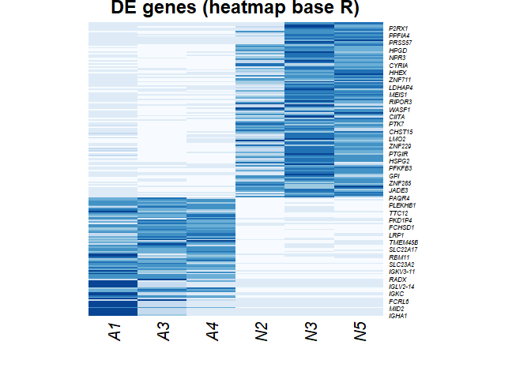

```r
# Paletas de colores para el heatmap
library(RColorBrewer)

# Crear heatmap base en R
figg_heatmap <- heatmap(
  dat2,
  Rowv = NA,                     # No agrupar genes (mantiene el orden)
  Colv = NA,                     # No agrupar columnas
  scale = "row",                 # Normalizar por fila (gen)
  main = "DE genes (heatmap base R)",
  col = brewer.pal(n = 8, name = "Blues")   # Paleta de colores azul
)
```

✔ Este heatmap es simple, pero útil para entender la estructura de los datos.

## 🎨 7. Heatmap con pheatmap (más profesional y flexible)

Si no tienes el paquete, instalarlo **install.packages(“pheatmap”)**

```r
# Cargar el paquete
library(pheatmap)

# Cerrar gráficos previos
dev.off()
```

```r
# Heatmap con pheatmap (mucho más customizable)
fig_pheatmap <- pheatmap(
  dat2,
  scale = "row",                     # Normaliza cada gen
  cluster_rows = FALSE,              # No reordena genes
  col = brewer.pal(n = 8, name = "Blues")
)
```

[output not shown]

## 🎨 Heatmap con leyenda personalizada

[figure not shown]

```r
pheatmap(
  dat2,
  scale = "row",
  cluster_rows = FALSE,
  col = brewer.pal(n = 8, name = "Blues"),
  legend_breaks = c(-2, 0, 2),                 # Niveles para la leyenda
  legend_labels = c("Low", "Medium", "High")   # Etiquetas interpretables
)
```